# Análisis de IDR

Jose Alberto Cabanes Madrid

2024-06-12

```r
library(ggplot2)
library(ggrepel)
library(readr)
```

Función para generar una lista de tramos desordenados. Tras ello, filtra los tramos desordenados, “fusionando” aquellos de tres o más residuos separados por regiones estructuradas de dos o menos residuos, y descartando los tramos desordenados de dos o menos residuos flanqueados por tramos estructurados de tres o más residuos.:

```r
idr <- function(df) {

# Variable para almacenar los tramos desordenados y, posteriormente, los tramos combinados y filtrados
tramos_desordenados <- list()
tramos_combinados <- list()
tramos_filtrados <- list()

# Variables auxiliares para registrar los límites de los tramos desordenados
inicio_tramo <- 1
en_desorden <- FALSE

# Iteración a través de las filas para identificar los tramos desordenados
for (i in 1:nrow(df)) {
  if (df$DESORDEN[i] == "desorden") {
    if (!en_desorden) {
      # Inicio de un nuevo tramo desordenado
      inicio_tramo <- i
      en_desorden <- TRUE
    }
  } else {
    if (en_desorden) {
      # Fin de un tramo desordenado
      tramos_desordenados <- c(tramos_desordenados, list(c(inicio_tramo, i - 1)))
      en_desorden <- FALSE
    }
  }
}

# Añadir el último tramo desordenado si termina en "desorden"
if (en_desorden) {
  tramos_desordenados <- c(tramos_desordenados, list(c(inicio_tramo, nrow(df))))
}

# Recorrer los tramos de desorden originales
for (tramo in tramos_desordenados) {
  inicio <- tramo[1]
  fin <- tramo[2]

  # Verificar longitud del tramo desordenado
  longitud_desorden <- fin - inicio + 1

  # Verificar si el tramo actual puede combinarse con el último tramo en tramos_combinados
  if (length(tramos_combinados) > 0) {
    ultimo_tramo <- tramos_combinados[[length(tramos_combinados)]]
    if (inicio - ultimo_tramo[2] <= 3) {
      # Fusionar tramos si están separados por uno o dos residuos "estructura"
      tramos_combinados[[length(tramos_combinados)]] <- c(ultimo_tramo[1], fin)
    } else {
      # Agregar tramo como nuevo si no se fusiona
      tramos_combinados <- c(tramos_combinados, list(tramo))
    }
  } else {
    # Primer tramo de desorden
    tramos_combinados <- c(tramos_combinados, list(tramo))
  }
}

# Filtrar tramos combinados para eliminar pequeños tramos de 1 o 2 residuos
for (tramo in tramos_combinados) {
  inicio <- tramo[1]
  fin <- tramo[2]

  # Verificar longitud del tramo desordenado
  longitud_desorden <- fin - inicio + 1

  # Verificar si el tramo debe ser filtrado
  if (longitud_desorden > 2 ||  # Mantener tramos de desorden largos
      (inicio > 1 && fin < nrow(df) &&  # Tramos de desorden flanqueados por estructura larga
       all(df$DESORDEN[(inicio - 2):(inicio - 1)] == "estructura") &&
       all(df$DESORDEN[(fin + 1):(fin + 1)] == "estructura")) ||
      (inicio == 1 && fin < nrow(df) &&  # Tramos de desorden al inicio flanqueados por estructura larga
       all(df$DESORDEN[(fin + 1):(fin + 1)] == "estructura")) ||
      (inicio > 1 && fin == nrow(df) &&  # Tramos de desorden al final flanqueados por estructura larga
       all(df$DESORDEN[(inicio - 2):(inicio - 1)] == "estructura"))) {

    tramos_filtrados <- c(tramos_filtrados, list(tramo))  # Mantener tramo filtrado
  }
}

print(tramos_filtrados)
}
```

## Proteína ELF4

Carga de datos de cada uno de los predictores:

```r
ELF4.IUPred2A <- read.delim("C:/Users/josea/OneDrive/Escritorio/Predicciones IDR/ELF4 IUPred2A.txt")

ELF4.AUCpreD <- read.table("C:/Users/josea/OneDrive/Escritorio/Predicciones IDR/ELF4 AUCpreD.diso_noprof", quote="\"",
                           col.names = c("POS", "AA", "IDR", "AUCPRED.SCORE"))
ELF4.DISOPred <- read.table("C:/Users/josea/OneDrive/Escritorio/Predicciones IDR/ELF4 DISOPred.comb", quote="\"",
                            col.names = c("POS", "AA", "IDR", "DISOPRED.SCORE"))
ELF4.PrDOS <- read_csv("C:/Users/josea/OneDrive/Escritorio/Predicciones IDR/ELF4 PrDOS.csv",
                       col_names = c("POS", "AA", "IDR", "PRDOS.SCORE"))
ELF4.flDPnn <- scan("C:/Users/josea/OneDrive/Escritorio/Predicciones IDR/ELF4 flDPnn.txt", sep = ",")
ELF4.flDPnn <- data.frame(POS = 1:111, FLDPNN.SCORE = ELF4.flDPnn)

ELF4.DisoFLAG <- scan("C:/Users/josea/OneDrive/Escritorio/Predicciones IDR/ELF4 DisoFLAG.txt", sep = ",")
ELF4.DisoFLAG <- data.frame(POS = 1:111, DISOFLAG.SCORE = ELF4.DisoFLAG)
```

Agrupación de datos en un solo dataframe:

```r
ELF4.IDR <- data.frame(
  POS = ELF4.IUPred2A$POS,
  IUPRED.SCORE = ELF4.IUPred2A$IUPRED.SCORE,
  AUCPRED.SCORE = ELF4.AUCpreD$AUCPRED.SCORE,
  DISOPRED.SCORE = ELF4.DISOPred$DISOPRED.SCORE,
  PRDOS.SCORE = ELF4.PrDOS$PRDOS.SCORE,
  DISOFLAG = ELF4.DisoFLAG$DISOFLAG.SCORE,
  FLDPNN.SCORE = ELF4.flDPnn$FLDPNN.SCORE
)
```

Establecer consenso de desorden por mayoría, si al menos 3 de los 5 algoritmos de predicción (omitiendo flDPnn) otorgan un valor igual o superior a 0.5:

```r
ELF4.IDR$DESORDEN <- "estructura"
ELF4.IDR$conteo_desorden <- rowSums(ELF4.IDR[, c("IUPRED.SCORE", "AUCPRED.SCORE", "DISOPRED.SCORE", "PRDOS.SCORE", "DISOFLAG")] >= 0.5)
ELF4.IDR$DESORDEN[ELF4.IDR$conteo_desorden >= 3] <- "desorden"
```

Listar y filtrar los tramos de desorden:

```r
ELF4_tramosIDR <- idr(ELF4.IDR)
```

```
## [[1]]
## [1]  1 26
##
## [[2]]
## [1]  95 111
```

```r
# Crear el dataframe desde la lista de listas
ELF4_tramosIDRdf <- do.call(rbind, lapply(ELF4_tramosIDR, function(x) data.frame(inicio = x[1], fin = x[2])))

saveRDS(ELF4_tramosIDRdf, file = "ELF4_tramosIDR.rds")
```

´ Representación:

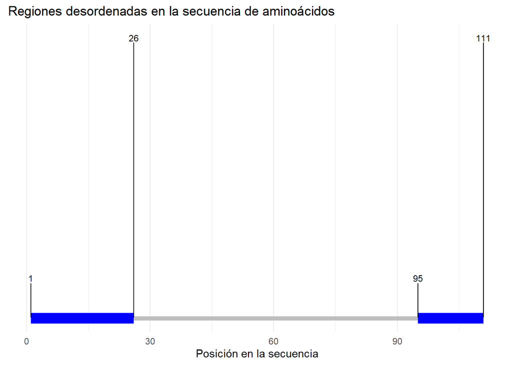

```r
ggplot() +
  # Línea horizontal que representa la secuencia completa
  geom_segment(aes(x = 1, xend = 111, y = 1, yend = 1), size = 2, color = "grey") +
  # Segmentos que representan las regiones desordenadas
  geom_segment(data = ELF4_tramosIDRdf, aes(x = inicio, xend = fin, y = 1, yend = 1), size = 5, color = "blue") +
  # Etiquetas para los valores de inicio y fin de cada tramo desordenado
  geom_text_repel(data = ELF4_tramosIDRdf, aes(x = inicio, y = 1, label = inicio),
                  size = 3, nudge_y = 0.1, color = "black", force = 1, max.overlaps = 2) +
  geom_text_repel(data = ELF4_tramosIDRdf, aes(x = fin, y = 1, label = fin),
                  size = 3, nudge_y = 0.7, color = "black", force = 1, max.overlaps = 2) +
  labs(title = "Regiones desordenadas en la secuencia de aminoácidos",
       x = "Posición en la secuencia",
       y = "") +
  theme_minimal() +
  theme(axis.text.y = element_blank(),
        axis.ticks.y = element_blank(),
        axis.title.y = element_blank(),
        panel.grid.major.y = element_blank(),
        panel.grid.minor.y = element_blank())
```

## Proteína LUX

Carga de datos de cada uno de los predictores:

```r
LUX.IUPred2A <- read.delim("C:/Users/josea/OneDrive/Escritorio/Predicciones IDR/LUX IUPred2A.txt")

LUX.AUCpreD <- read.table("C:/Users/josea/OneDrive/Escritorio/Predicciones IDR/LUX AUCpreD.diso_noprof", quote="\"",
                           col.names = c("POS", "AA", "IDR", "AUCPRED.SCORE"))
LUX.DISOPred <- read.table("C:/Users/josea/OneDrive/Escritorio/Predicciones IDR/LUX DISOPred.comb", quote="\"",
                            col.names = c("POS", "AA", "IDR", "DISOPRED.SCORE"))
LUX.PrDOS <- read_csv("C:/Users/josea/OneDrive/Escritorio/Predicciones IDR/LUX PrDOS.csv",
                       col_names = c("POS", "AA", "IDR", "PRDOS.SCORE"))
LUX.flDPnn <- scan("C:/Users/josea/OneDrive/Escritorio/Predicciones IDR/LUX flDPnn.txt", sep = ",")
LUX.flDPnn <- data.frame(POS = 1:323, FLDPNN.SCORE = LUX.flDPnn)

LUX.DisoFLAG <- scan("C:/Users/josea/OneDrive/Escritorio/Predicciones IDR/LUX DisoFLAG.txt", sep = ",")
LUX.DisoFLAG <- data.frame(POS = 1:323, DISOFLAG.SCORE = LUX.DisoFLAG)
```

Agrupación de datos en un solo dataframe:

```r
LUX.IDR <- data.frame(
  POS = LUX.IUPred2A$POS,
  IUPRED.SCORE = LUX.IUPred2A$IUPRED.SCORE,
  AUCPRED.SCORE = LUX.AUCpreD$AUCPRED.SCORE,
  DISOPRED.SCORE = LUX.DISOPred$DISOPRED.SCORE,
  PRDOS.SCORE = LUX.PrDOS$PRDOS.SCORE,
  DISOFLAG = LUX.DisoFLAG$DISOFLAG.SCORE,
  FLDPNN.SCORE = LUX.flDPnn$FLDPNN.SCORE
)
```

Establecer consenso de desorden por mayoría, si al menos 3 de los 5 algoritmos de predicción (omitiendo flDPnn) otorgan un valor igual o superior a 0.5:

```r
LUX.IDR$DESORDEN <- "estructura"
LUX.IDR$conteo_desorden <- rowSums(LUX.IDR[, c("IUPRED.SCORE", "AUCPRED.SCORE", "DISOPRED.SCORE", "PRDOS.SCORE", "DISOFLAG")] >= 0.5)
LUX.IDR$DESORDEN[LUX.IDR$conteo_desorden >= 3] <- "desorden"
```

Listar y filtrar los tramos de desorden:

```r
LUX_tramosIDR <- idr(LUX.IDR)
```

```
## [[1]]
## [1]  1 18
##
## [[2]]
## [1]  56 141
##
## [[3]]
## [1] 206 217
##
## [[4]]
## [1] 227 239
##
## [[5]]
## [1] 261 297
##
## [[6]]
## [1] 310 323
```

```r
# Crear el dataframe desde la lista de listas
LUX_tramosIDRdf <- do.call(rbind, lapply(LUX_tramosIDR, function(x) data.frame(inicio = x[1], fin = x[2])))

saveRDS(LUX_tramosIDRdf, file = "LUX_tramosIDR.rds")
```

Representación:

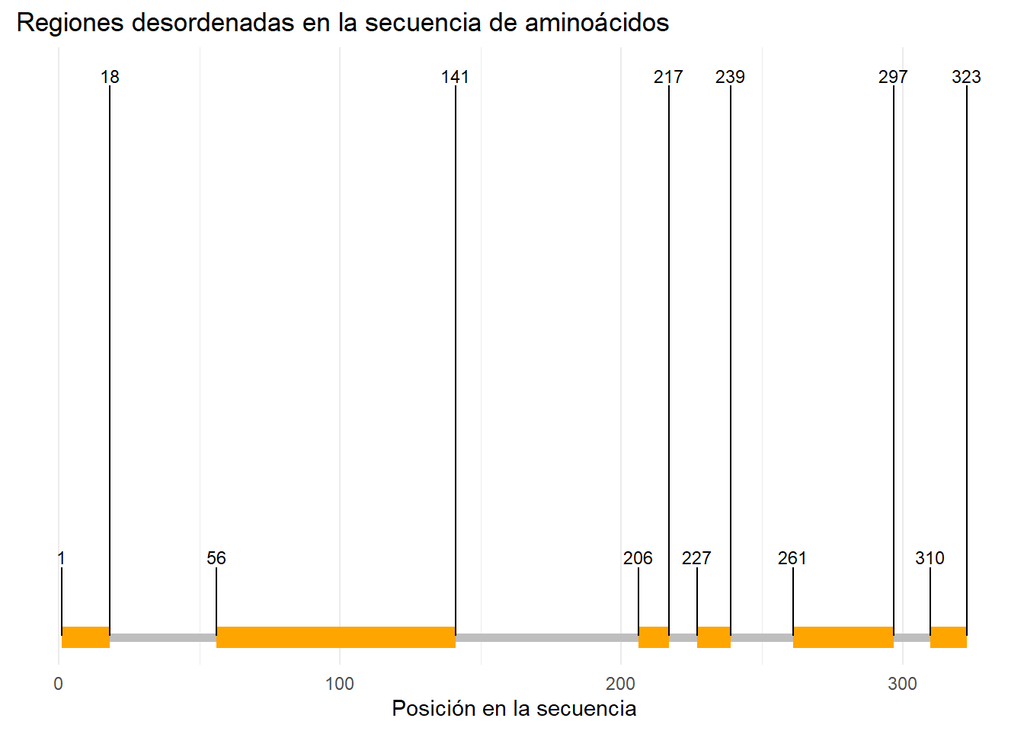

```r
ggplot() +
  # Línea horizontal que representa la secuencia completa
  geom_segment(aes(x = 1, xend = 323, y = 1, yend = 1), size = 2, color = "grey") +
  # Segmentos que representan las regiones desordenadas
  geom_segment(data = LUX_tramosIDRdf, aes(x = inicio, xend = fin, y = 1, yend = 1), size = 5, color = "orange") +
  # Etiquetas para los valores de inicio y fin de cada tramo desordenado
  geom_text_repel(data = LUX_tramosIDRdf, aes(x = inicio, y = 1, label = inicio),
                  size = 3, nudge_y = 0.1, color = "black", force = 1, max.overlaps = 2) +
  geom_text_repel(data = LUX_tramosIDRdf, aes(x = fin, y = 1, label = fin),
                  size = 3, nudge_y = 0.7, color = "black", force = 1, max.overlaps = 2) +
  labs(title = "Regiones desordenadas en la secuencia de aminoácidos",
       x = "Posición en la secuencia",
       y = "") +
  theme_minimal() +
  theme(axis.text.y = element_blank(),
        axis.ticks.y = element_blank(),
        axis.title.y = element_blank(),
        panel.grid.major.y = element_blank(),
        panel.grid.minor.y = element_blank())
```

## Proteína ELF3

Carga de datos de cada uno de los predictores:

```r
ELF3.IUPred2A <- read.delim("C:/Users/josea/OneDrive/Escritorio/Predicciones IDR/ELF3 IUPred2A.txt")

ELF3.AUCpreD <- read.table("C:/Users/josea/OneDrive/Escritorio/Predicciones IDR/ELF3 AUCpreD.diso_noprof", quote="\"",
                           col.names = c("POS", "AA", "IDR", "AUCPRED.SCORE"))
ELF3.DISOPred <- read.table("C:/Users/josea/OneDrive/Escritorio/Predicciones IDR/ELF3 DISOPred.comb", quote="\"",
                            col.names = c("POS", "AA", "IDR", "DISOPRED.SCORE"))
ELF3.PrDOS <- read_csv("C:/Users/josea/OneDrive/Escritorio/Predicciones IDR/ELF3 PrDOS.csv",
                       col_names = c("POS", "AA", "IDR", "PRDOS.SCORE"))
ELF3.flDPnn <- scan("C:/Users/josea/OneDrive/Escritorio/Predicciones IDR/ELF3 flDPnn.txt", sep = ",")
ELF3.flDPnn <- data.frame(POS = 1:695, FLDPNN.SCORE = ELF3.flDPnn)

ELF3.DisoFLAG <- scan("C:/Users/josea/OneDrive/Escritorio/Predicciones IDR/ELF3 DisoFLAG.txt", sep = ",")
ELF3.DisoFLAG <- data.frame(POS = 1:695, DISOFLAG.SCORE = ELF3.DisoFLAG)
```

Agrupación de datos en un solo dataframe:

```r
ELF3.IDR <- data.frame(
  POS = ELF3.IUPred2A$POS,
  IUPRED.SCORE = ELF3.IUPred2A$IUPRED.SCORE,
  AUCPRED.SCORE = ELF3.AUCpreD$AUCPRED.SCORE,
  DISOPRED.SCORE = ELF3.DISOPred$DISOPRED.SCORE,
  PRDOS.SCORE = ELF3.PrDOS$PRDOS.SCORE,
  DISOFLAG = ELF3.DisoFLAG$DISOFLAG.SCORE,
  FLDPNN.SCORE = ELF3.flDPnn$FLDPNN.SCORE
)
```

Establecer consenso de desorden por mayoría, si al menos 3 de los 5 algoritmos de predicción (omitiendo flDPnn) otorgan un valor igual o superior a 0.5:

```r
ELF3.IDR$DESORDEN <- "estructura"
ELF3.IDR$conteo_desorden <- rowSums(ELF3.IDR[, c("IUPRED.SCORE", "AUCPRED.SCORE", "DISOPRED.SCORE", "PRDOS.SCORE", "DISOFLAG")] >= 0.5)
ELF3.IDR$DESORDEN[ELF3.IDR$conteo_desorden >= 3] <- "desorden"
```

Listar y filtrar los tramos de desorden:

```r
ELF3_tramosIDR <- idr(ELF3.IDR)
```

```
## [[1]]
## [1]   1 125
##
## [[2]]
## [1] 130 312
##
## [[3]]
## [1] 378 383
##
## [[4]]
## [1] 404 447
##
## [[5]]
## [1] 451 451
##
## [[6]]
## [1] 540 655
##
## [[7]]
## [1] 685 695
```

```r
# Crear el dataframe desde la lista de listas
ELF3_tramosIDRdf <- do.call(rbind, lapply(ELF3_tramosIDR, function(x) data.frame(inicio = x[1], fin = x[2])))

saveRDS(ELF3_tramosIDRdf, file = "ELF3_tramosIDR.rds")
```

Representación:

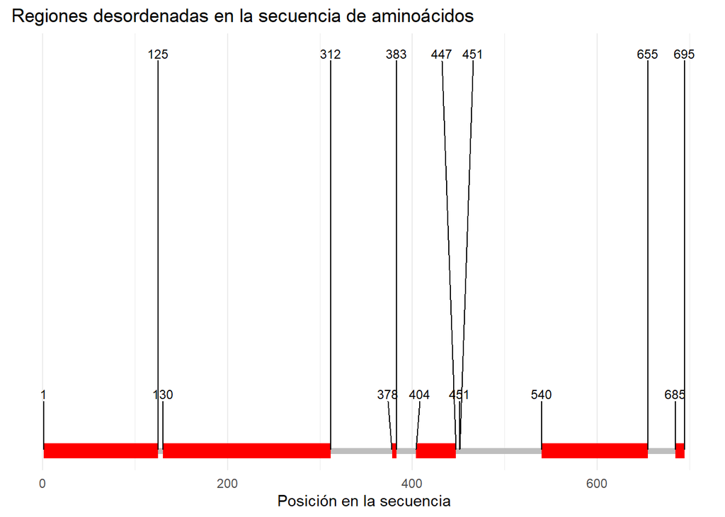

```r
ggplot() +
  # Línea horizontal que representa la secuencia completa
  geom_segment(aes(x = 1, xend = 695, y = 1, yend = 1), size = 2, color = "grey") +
  # Segmentos que representan las regiones desordenadas
  geom_segment(data = ELF3_tramosIDRdf, aes(x = inicio, xend = fin, y = 1, yend = 1), size = 5, color = "red") +
  # Etiquetas para los valores de inicio y fin de cada tramo desordenado
  geom_text_repel(data = ELF3_tramosIDRdf, aes(x = inicio, y = 1, label = inicio),
                  size = 3, nudge_y = 0.1, color = "black", force = 1, max.overlaps = 2) +
  geom_text_repel(data = ELF3_tramosIDRdf, aes(x = fin, y = 1, label = fin),
                  size = 3, nudge_y = 0.7, color = "black", force = 1, max.overlaps = 2) +
  labs(title = "Regiones desordenadas en la secuencia de aminoácidos",
       x = "Posición en la secuencia",
       y = "") +
  theme_minimal() +
  theme(axis.text.y = element_blank(),
        axis.ticks.y = element_blank(),
        axis.title.y = element_blank(),
        panel.grid.major.y = element_blank(),
        panel.grid.minor.y = element_blank())
```